# Numerical Methods for Differential Equations

MATH 341 — Notes 14

University of Scranton

2026-10-04

# Goals

## What We Will Cover

1. **Why numerical methods?** — analytic solutions are the exception, not the rule
2. **Euler method** (§6.2.1) — derivation, geometric picture, $O(h)$ global error
3. **Modified Euler / RK2** — predictor–corrector, $O(h^2)$ global error
4. **Runge–Kutta RK4** (§6.2.2) — four slopes, $O(h^4)$ global error
5. **Error analysis** — truncation, stability, roundoff; stiff equations
6. **Systems** (§6.3) — extending all methods to $x'=f(t,x,y)$, $y'=g(t,x,y)$
7. **`scipy.integrate.solve_ivp`** — practical adaptive solver usage

**Note**

**Sections 6.2 and 6.3** of (Logan 2015).

**Tip**

New vocabulary: step size, local truncation error, global error, explicit/implicit, predictor–corrector, adaptive step size, stiff equation.

# Why Numerical Methods?

## The Reality of ODEs in Practice

Most DEs arising in science and engineering **cannot** be solved analytically:

- The force $F(x,x')$ is nonlinear (pendulum, van der Pol, …)
- Parameters are time-varying or data-driven
- The model is a large coupled system

Even when an analytic solution exists, it may involve complicated integrals or infinite series requiring numerical evaluation anyway.

**Logan:** *“Many would say that the material in this brief section is the most important in the entire book.”*

**The plan:** replace the continuous IVP

$$x' = f(t,x), \quad x(t_0)=x_0 \tag{6.3}$$

with a **discrete recursive formula** that a computer can evaluate step by step.

## Discretization

Divide $[t_0, T]$ into $N$ equal subintervals of length

$$h = \frac{T - t_0}{N} \qquad \text{(step size)}.$$

Grid: $t_n = t_0 + nh$, $n = 0,1,\ldots,N$.

**Goal:** find a recursive formula $X_{n+1} = \Phi(t_n, X_n, h)$ such that

$$X_n \approx x(t_n) \quad \text{for all } n.$$

Starting from $X_0 = x_0$, apply the formula $N$ times.

| Quantity | Meaning |
| --- | --- |
| $x(t_n)$ | True solution at grid point |
| $X_n$ | Numerical approximation |
| $x(t_n)-X_n$ | Error at step $n$ |

# The Euler Method

## Derivation

Integrate $x'(t)=f(t,x(t))$ from $t_n$ to $t_{n+1}$:

$$\int_{t_n}^{t_{n+1}} x'(t)\,dt = \int_{t_n}^{t_{n+1}} f(t,x(t))\,dt. \tag{6.4}$$

Left side: $x(t_{n+1})-x(t_n)$ (Fundamental Theorem).

Right side: **left-hand rectangle rule** — approximate $f$ by its value at $t_n$:

$$x(t_{n+1}) = x(t_n) + h\,f(t_n,x(t_n)) + \underbrace{O(h^2)}_{\text{local error}}.$$

Drop the error term, write $X_n \approx x(t_n)$:

**Euler Method (6.5)**

$$\boxed{X_{n+1} = X_n + h\,f(t_n, X_n)}, \quad X_0 = x_0.$$

**Explicit** — $X_{n+1}$ computed directly. **Global error:** $O(h)$.

## Geometric Picture — The Animation

At each step: **follow the slope field** at the current point for distance $h$.

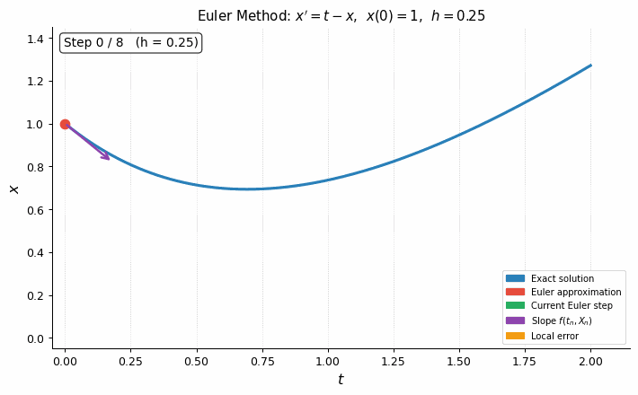

Euler method: $x'=t-x$, $x(0)=1$, $h=0.25$. Green = Euler step (local tangent); orange = local error; blue = exact solution; red = numerical approximation.

## Error Analysis

| Error type | Order | Meaning |
| --- | --- | --- |
| Local truncation | $O(h^2)$ | Error over **one** step |
| Global (cumulative) | $O(h)$ | Error over **all** $N=\frac{T-t_0}{h}$ steps |

**Consequence of** $O(h)$ **global error:**

Halving $h$ (doubling $N$) **halves** the global error.

From Example 6.3 ($x'=t-x$, $x(0)=1$, exact $x(2)=1.2707$):

| $h$ | $X_8$ (approx) | Error |
| --- | --- | --- |
| 0.5 | 1.125 | 0.1457 |
| 0.25 | 1.2002 | 0.0705 |
| 0.125 | 1.2361 | 0.0346 |

Error approximately **halved** each time $h$ is halved. ✓

## Example 6.3 — Euler Convergence

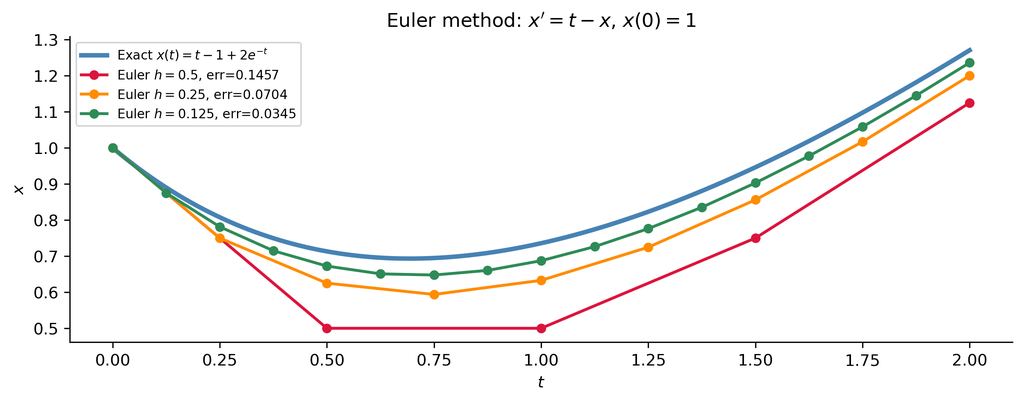

Figure 1

# Modified Euler and RK4

## Modified Euler (RK2) — Predictor–Corrector

**Idea:** use the **trapezoidal rule** instead of the rectangle rule for the integral in (6.4):

$$x(t_{n+1})-x(t_n) = \frac{h}{2}\bigl[f(t_n,x(t_n))+f(t_{n+1},x(t_{n+1}))\bigr]+O(h^3).$$

This gives an implicit equation. Fix it with a **predictor–corrector**:

**Modified Euler / RK2**

**Predictor** (Euler step):
$$\widetilde{X}_{n+1} = X_n + h\,f(t_n, X_n). \tag{6.7}$$

**Corrector** (trapezoidal average):
$$X_{n+1} = X_n + \frac{h}{2}\bigl[f(t_n,X_n) + f(t_{n+1},\widetilde{X}_{n+1})\bigr]. \tag{6.8}$$

**Global error: $O(h^2)$** — halving $h$ quarters the error.

## The Runge–Kutta Method (RK4)

The **workhorse** of numerical ODEs. Evaluates $f$ at four points per step:

**RK4 Update**

$$X_{n+1} = X_n + \frac{h}{6}(k_1 + 2k_2 + 2k_3 + k_4),$$

$$k_1 = f(t_n,\;X_n), \qquad k_2 = f\!\left(t_n+\tfrac{h}{2},\;X_n+\tfrac{h}{2}k_1\right),$$
$$k_3 = f\!\left(t_n+\tfrac{h}{2},\;X_n+\tfrac{h}{2}k_2\right), \qquad k_4 = f(t_n+h,\;X_n+hk_3).$$

**Global error: $O(h^4)$** — halving $h$ reduces error by factor of 16.

## Method Comparison

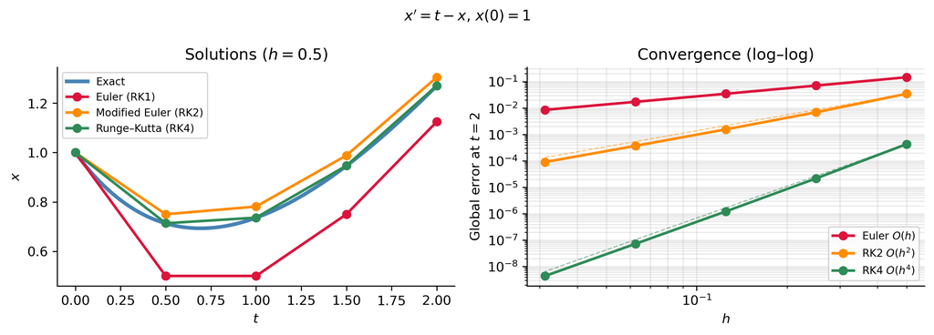

Figure 2

## Error Sources and Stiff Equations

Three sources of error in any finite difference scheme:

- **Truncation error** — from approximating a continuous problem by a discrete one. This is the $O(h^p)$ analysis we have been doing.
- **Stability error** — the discrete algorithm itself may be unstable. An early error can be amplified exponentially as it propagates forward. The step size $h$ must stay below a problem-dependent threshold.
- **Roundoff error** — computers represent real numbers with finite precision. The actually computed $\overline{X}_n$ differs from the exact discrete $X_n$; reducing $h$ too far eventually makes roundoff dominate.

To help develop our intuition for these numerical methods, let’s view [this visual web app](https://math341diffeq.netlify.app/viz_numerical).

**Stiff Equations**

A DE is **stiff** when the solution has components that change at vastly different time scales. Euler and even RK4 require extremely small $h$ for stability. Use **implicit solvers** (backward Euler, `method='Radau'` or `'BDF'` in `solve_ivp`).

# Systems of Equations

## Extending to Systems (§6.3)

For the 2D system $x'=f(t,x,y)$, $y'=g(t,x,y)$, $x(t_0)=x_0$, $y(t_0)=y_0$:

**Euler:**
$$X_{n+1}=X_n+hf(t_n,X_n,Y_n), \quad Y_{n+1}=Y_n+hg(t_n,X_n,Y_n).$$

**Modified Euler** — predictors then correctors (same structure, applied to both components simultaneously).

**RK4** — compute **eight slopes** $k_{11},k_{21},k_{12},k_{22},k_{13},k_{23},k_{14},k_{24}$ (one pair per component at each of the four evaluation points), then:

$$X_{n+1}=X_n+\frac{h}{6}(k_{11}+2k_{12}+2k_{13}+k_{14}),$$
$$Y_{n+1}=Y_n+\frac{h}{6}(k_{21}+2k_{22}+2k_{23}+k_{24}).$$

**Global errors remain $O(h)$, $O(h^2)$, $O(h^4)$.** The procedure extends to any number of equations.

# scipy.integrate.solve_ivp

## Why Use `solve_ivp`?

Rather than coding methods from scratch, use `scipy.integrate.solve_ivp`:

- **Adaptive step size**: automatically tightens $h$ where the solution changes rapidly, relaxes it where it is smooth.
- **Multiple solvers**: `'RK45'` (default), `'RK23'`, `'DOP853'`, `'Radau'` (stiff), `'BDF'` (stiff).
- **Dense output**: continuous interpolant `sol.sol(t)` for plotting.
- **Event detection**: find zero-crossings (e.g., when a population hits zero).

**Basic Call Pattern**

```python
from scipy.integrate import solve_ivp

sol = solve_ivp(
    fun    = lambda t, y: [f(t, y[0])],  # rhs: (t, y-vector) → dy/dt vector
    t_span = (t0, T),                     # integration interval
    y0     = [x0],                        # initial condition (list/array)
    method = 'RK45',                      # solver
    dense_output = True,                  # enable sol.sol(t) interpolant
    rtol   = 1e-6,                        # relative tolerance
    atol   = 1e-8,                        # absolute tolerance
)
```

## `solve_ivp` — Single Equation

```python
sol = solve_ivp(
    fun          = lambda t, y: [t - y[0]],
    t_span       = (0, 2),
    y0           = [1.0],
    method       = 'RK45',
    dense_output = True,
    rtol=1e-6, atol=1e-8,
)
print(f"Steps: {len(sol.t)}   x(2) ≈ {sol.y[0,-1]:.8f}   exact: {exact_ex(2):.8f}")
```

```
Steps: 11   x(2) ≈ 1.27067069   exact: 1.27067057
```

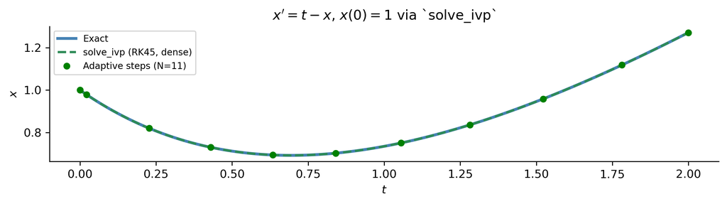

Figure 4

## `solve_ivp` — System Example (Lotka–Volterra)

```python
a, b, c, d = 0.6, 0.5, 0.3, 0.4
sol_lv = solve_ivp(
    fun = lambda t, z: [a*z[0]-b*z[0]*z[1],   # x' = ax - bxy
                        -c*z[1]+d*z[0]*z[1]],  # y' = -cy + dxy
    t_span = (0, 60),
    y0     = [c/d + 0.4, a/b],
    method = 'RK45',
    dense_output = True,
    rtol=1e-9, atol=1e-11, max_step=0.05,
)
```

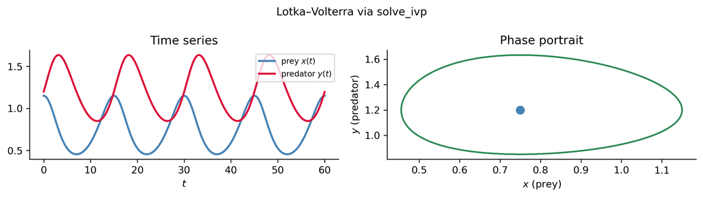

Figure 5

## Solver Selection Guide

| Situation | Recommended solver |
| --- | --- |
| General non-stiff (default) | `'RK45'` |
| Higher accuracy needed | `'DOP853'` |
| Stiff system (large eigenvalue spread) | `'Radau'` or `'BDF'` |
| Unknown stiffness | Try `'RK45'`; if slow/fails → `'Radau'` |

**Key tolerances:**

- `rtol` (relative tolerance, default `1e-3`): controls relative accuracy. Tighten to `1e-6` for physics/engineering work.
- `atol` (absolute tolerance, default `1e-6`): important when solution passes through zero.

**Tip**

**Rule of thumb:** for most problems in this course, `solve_ivp(fun, t_span, y0, method='RK45', rtol=1e-6, atol=1e-8, dense_output=True)` is more than sufficient.

# Summary

## Key Takeaways

- The **Euler method** (6.5) $X_{n+1}=X_n+hf(t_n,X_n)$ follows the slope field step by step. It is first-order: global error $O(h)$, so halving $h$ halves the error.
- The **modified Euler / RK2** method uses a predictor–corrector pair (6.7)–(6.8). Global error $O(h^2)$: halving $h$ quarters the error.
- **Runge–Kutta RK4** uses a weighted average of four slope evaluations $k_1,\ldots,k_4$. Global error $O(h^4)$: halving $h$ reduces error by a factor of 16. RK4 is the standard workhorse of numerical ODE solving.
- All three methods extend to **systems** by treating the state as a vector and applying the formula component-wise. Error orders are unchanged.
- **Error sources:** truncation (Taylor series), stability (scheme may amplify errors), and roundoff (finite-precision arithmetic). **Stiff equations** require implicit solvers.
- **`scipy.integrate.solve_ivp`** provides high-quality adaptive RK solvers with automatic step-size control. Use `dense_output=True` for a continuous interpolant, `method='Radau'` for stiff problems, and always tighten `rtol`/`atol` for accuracy-sensitive work.

**Tip**

**Looking Ahead:** The numerical tools developed here — especially `solve_ivp` — are the practical foundation for everything in Chapters 4 and 5: every phase portrait, every time series for a nonlinear system, every stability analysis we could not do by hand.

**Note**

**Next:** Review and additional computational topics.

## References

Logan, J David. 2015. *A First Course in Differential Equations, Third Edition*.